# Deskriptiv statistik

Alexander Matzen alexander@amatzen.dk

11/09/2020

## Opgave 1

Anvend tilfældige tal funktionen i R til at generere et normalfordelt datasæt på 500 observationer med middelværdi lig 70 og standardafvigelse lig 15. Lav en passende grafisk præsentation.

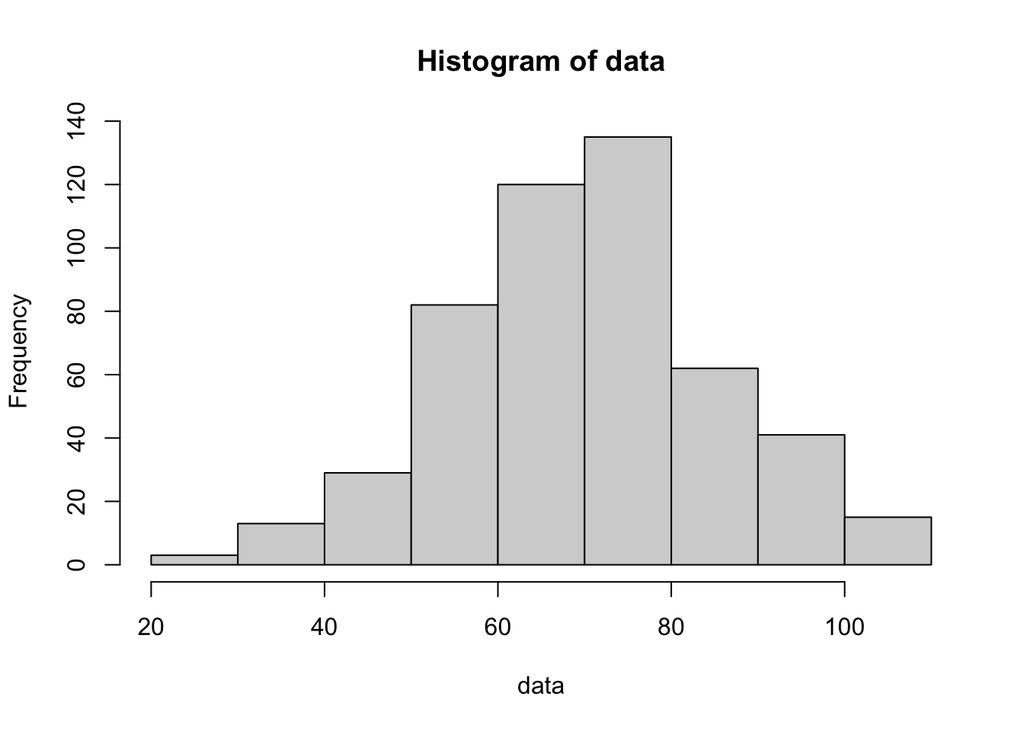

```r
amountData <- 500
mean <- 70
standardDeviation <- 15

data <- rnorm(amountData, mean = mean, sd = standardDeviation)
hist(data)
```

## Opgave 2

I ”Champinon Vinyl” - en butik, der udelukkende forhandler gamle LP-plader (Forretningens navn er hentet fra Nick Hornby’s roman ”High Fidelity”), har man på 30 forskellige dage i en tilfældig måned registreret antallet af kunder per dag til:

### Delopgave a

```r
# Indsætter data i en vektor (c)
data <- c(72,89,78,87,86,40,73,83,77,82,70,60,63,56,59,72,44,28,68,69,98,52,68,74,53,84,81,77,73,71)


print(paste(
  "Antal observationer: ",
  format(length(data),digits = 4)
))
```

```
[1] "Antal observationer:  30"
```

```r
print(paste(
  "Middeltal / Gennemsnit: ",
  format(mean(data), digits = 4)
))
```

```
[1] "Middeltal / Gennemsnit:  69.57"
```

```r
print(paste(
  "Standardafvigelsen / Spredning: ",
  format(sd(data), digits = 4)
))
```

```
[1] "Standardafvigelsen / Spredning:  15.48"
```

```r
summary(data)
```

```
   Min. 1st Qu.  Median    Mean 3rd Qu.    Max.
  28.00   60.75   72.00   69.57   80.25   98.00
```

Der er gennemsnitligt omkring 70 kunder i butikken pr. dag i observationsperioden. Den gennemsnitlige variation fra denne er på 15 kunder. Der er minimum 28 kunder på en dag, og maksimalt 98 kunder på en dag i observationsperioden.

### Delopgave b

Lav en grafisk afbildning af antal kunder per dag. (Histogram) ved anvendelse af R Anvend en fornuftig opdeling af intervaller. Kommenter fordelingen.

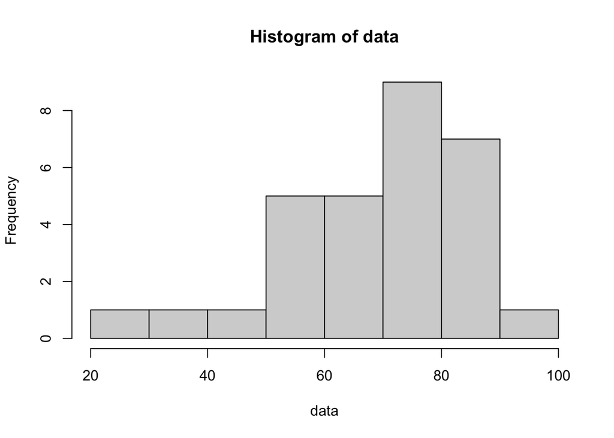

```r
hist(data)
```

### Delopgave c

Angiv 5-punktsopsummeringen og kvartilafstanden.

```r
library(knitr)

print(fivenum(data))
```

```
[1] 28 60 72 81 98
```

```r
writeLines("")
```

```r
writeLines("Kvartilsæt:")
```

```
Kvartilsæt:
```

```r
print(quantile(data))
```

```
   0%   25%   50%   75%  100%
28.00 60.75 72.00 80.25 98.00
```

### Delopgave d

Anvend R til at opstille et boksdiagram for materialet.

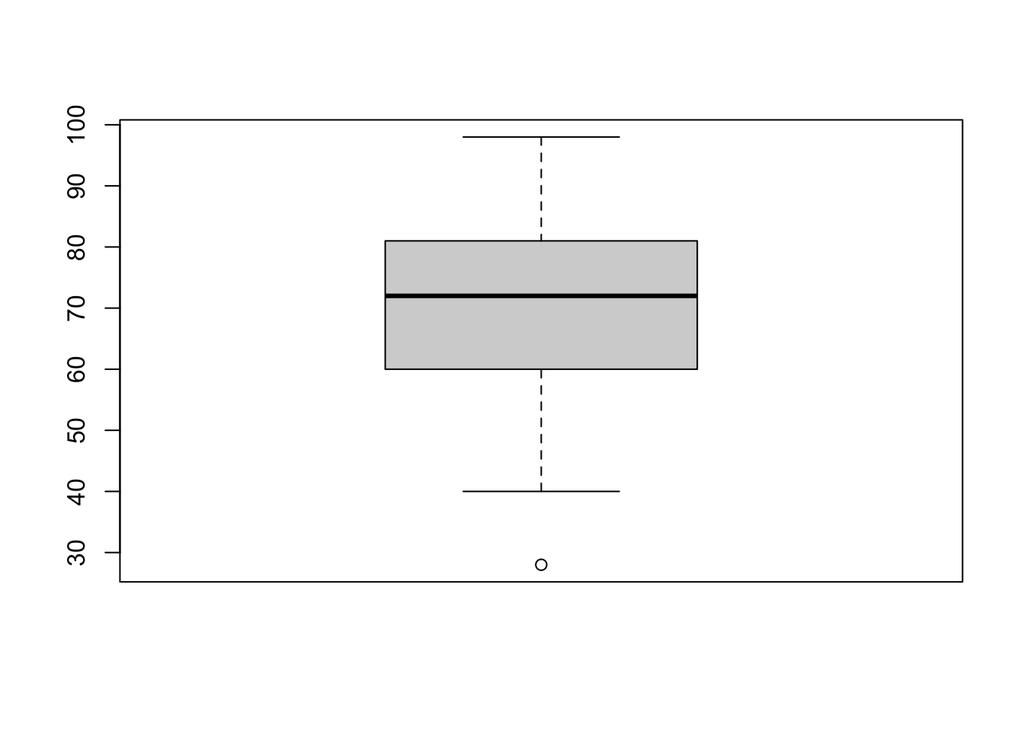

```r
boxplot(data)
```

### Delopgave e

Sammenlign fordelingen i dette datasæt med den, som blev fundet i opgave 1.

Der er en væsentlig skævfordeling. Observationerne i opgave 1 var mere ligefordelt og distribueret, hvor at observationerne i opgave 2 var mere skævfordelt til fordel for flere dage med flere kunder i observationsperioden.

## Opgave 3

Den første januar 2008 publicerede dagbladet “Politiken” resultaterne af en quiz, som dagbladet havde udskrevet nøjagtig et år tidligere. Man stillede 15 spørgsmål til begivenheder, som kunne have fundet sted i året 2007. For eksempel ”Vil Fidel Castro afgå ved døden i 2007 (han lever som bekendt stadig)”?

### Delopgave a

Beregn det gennemsnitlige antal korrekte svar og standardafvigelsen

```r
replies <- c(0, 0, 0, 15, 119, 522, 1451, 2490, 2808, 2265, 1210, 407, 122, 24, 2, 0)
correctReplies <- c(0, 1, 2, 3, 4, 5, 6, 7, 8, 9, 10, 11, 12, 13, 14, 15)

#data <- matrix(c(correctReplies, replies), nrow = 16, ncol = 2, byrow = FALSE)
data <- data.frame(
    "KorrekteSvar" = correctReplies,
    "Hyppighed" = replies
)

print(paste(
    "Totale svar: ",
    sum(replies)
))
```

```
[1] "Totale svar:  11435"
```

```r
print(paste(
    "Gennemsnitligt antal korrekte svar: ",
    format(
        mean(rep(data$KorrekteSvar, data$Hyppighed)), # tilsvarende til sum(replies*correctReplies)/sum(replies)
        digits = 3
    )
))
```

```
[1] "Gennemsnitligt antal korrekte svar:  7.91"
```

```r
print(paste(
    "Standardafvigelsen: ",
    format(
        sd(rep(data$KorrekteSvar, data$Hyppighed)),
        digits = 3
    )
))
```

```
[1] "Standardafvigelsen:  1.58"
```

## Opgave 4

Nedenstående datasæt beskriver den gennemsnitlige opkaldstid i sekunder for en række forskellige operatører i et call-center. Beregn gennemsnit og kvartiler. Foretag på denne baggrund en undersøgelse for ekstreme observationer i materialet. Anvend R.

```r
data <- c(7.0,6.9,8.2,7.8,7.7,7.3,6.8,6.7,8.2,8.4,7.0,6.7,7.5,7.2,7.9,7.6,6.7,6.3,6.6,5.6,7.8,5.5,6.2,5.8,6.1,5.8,6.0,7.3,7.5,7.3,7.2,7.4,7.2,7.6)

g_data <- cut(data, 5) # Grupperer dataen i 5 intervaller
g_data <- table(g_data) # Gør at dataen bliver opstillet som hyppighedstabel

print(paste(
    "Gennemsnitlig svartid:",
    format(
        mean(g_data),
        digits = 3
    ), "sekunder"
))
```

```
[1] "Gennemsnitlig svartid: 6.8 sekunder"
```

```r
writeLines("")
```

```r
writeLines("Kvartilsæt:")
```

```
Kvartilsæt:
```

```r
print(quantile(g_data))
```

```
  0%  25%  50%  75% 100%
   4    4    5   10   11
```